# Reproducible Research: Peer Assessment 1

## Loading and preprocessing the data

```r
# load the required libraries
library(ggplot2)
library(dplyr)
library(tidyverse)
library(magrittr)
#unzip the file and load the data

unzip("./activity.zip")
data1 <-read.csv("./activity.csv")
head(data1)
```

```
##   steps       date interval
## 1    NA 2012-10-01        0
## 2    NA 2012-10-01        5
## 3    NA 2012-10-01       10
## 4    NA 2012-10-01       15
## 5    NA 2012-10-01       20
## 6    NA 2012-10-01       25
```

```r
summary(data1)
```

```
##      steps            date              interval
##  Min.   :  0.00   Length:17568       Min.   :   0.0
##  1st Qu.:  0.00   Class :character   1st Qu.: 588.8
##  Median :  0.00   Mode  :character   Median :1177.5
##  Mean   : 37.38                      Mean   :1177.5
##  3rd Qu.: 12.00                      3rd Qu.:1766.2
##  Max.   :806.00                      Max.   :2355.0
##  NA's   :2304
```

## What is total number of steps taken per day?

```r
#drop NAs just for the first question
data_NoNA <- data1%>%
            drop_na()
```

```r
total_stepsperday<-aggregate(x= data_NoNA$steps,
          by = list(data_NoNA$date),
          FUN = sum)
total_stepsperday
```

```
##       Group.1     x
## 1  2012-10-02   126
## 2  2012-10-03 11352
## 3  2012-10-04 12116
## 4  2012-10-05 13294
## 5  2012-10-06 15420
## 6  2012-10-07 11015
## 7  2012-10-09 12811
## 8  2012-10-10  9900
## 9  2012-10-11 10304
## 10 2012-10-12 17382
## 11 2012-10-13 12426
## 12 2012-10-14 15098
## 13 2012-10-15 10139
## 14 2012-10-16 15084
```

[output cut: 39 more lines]

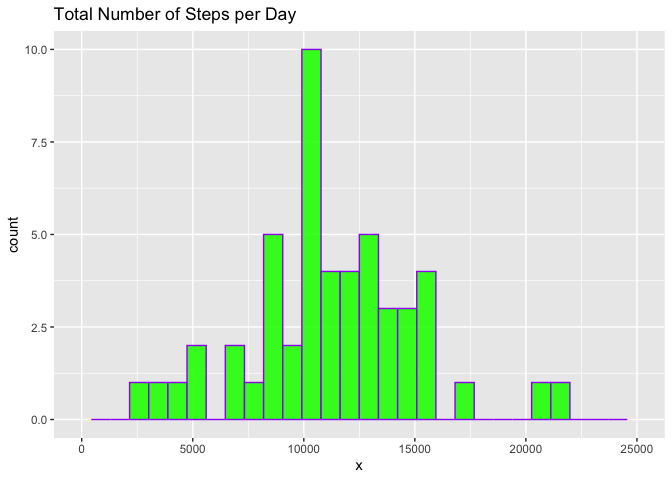

```r
steps_hist<- total_stepsperday %>%
            ggplot(aes(x=x)) +
            geom_histogram(fill="green",color = "purple", alpha=0.9)+
ggtitle("Total Number of Steps per Day")+
xlim(0, 25000)
steps_hist
```

## Mean and Median of Total number of steps taken per day

### Mean of Total number of steps

```r
mean(total_stepsperday$x)
```

```
## [1] 10766.19
```

The mean total number of steps taken per day is 10766.19

### Median of Total number of steps

```r
median(total_stepsperday$x)
```

```
## [1] 10765
```

The median total number of steps is 10765. There is not much of a difference between the mean and the median number of steps taken per day.

## What is the average daily activity pattern?

```r
#aggregate steps by interval
total_stepsperint<-aggregate(x= data_NoNA$steps,
          by = list(data_NoNA$interval),
          FUN = mean)
total_stepsperint
```

```
##     Group.1           x
## 1         0   1.7169811
## 2         5   0.3396226
## 3        10   0.1320755
## 4        15   0.1509434
## 5        20   0.0754717
## 6        25   2.0943396
## 7        30   0.5283019
## 8        35   0.8679245
## 9        40   0.0000000
## 10       45   1.4716981
## 11       50   0.3018868
## 12       55   0.1320755
## 13      100   0.3207547
## 14      105   0.6792453
```

[output cut: 274 more lines]

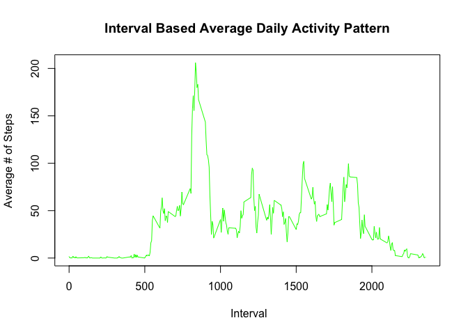

```r
steps_timeseries <- plot(x~ Group.1, data=total_stepsperint, type="l", col="green", main = "Interval Based Average Daily Activity Pattern", xlab = " Interval", ylab = "Average # of Steps" )
```

## Which 5-minute interval, on average across all the days in the dataset, contains the maximum number of steps

```r
#p<-max(total_stepsperint$x)
int_max_steps<-total_stepsperint[which.max(total_stepsperint$x),]
int_max_steps
```

```
##     Group.1        x
## 104     835 206.1698
```

Interval 835 contains the maximum average steps of 206.16

## Imputing missing values

### Calculating the total number of missing values

```r
summary(data1)
```

```
##      steps            date              interval
##  Min.   :  0.00   Length:17568       Min.   :   0.0
##  1st Qu.:  0.00   Class :character   1st Qu.: 588.8
##  Median :  0.00   Mode  :character   Median :1177.5
##  Mean   : 37.38                      Mean   :1177.5
##  3rd Qu.: 12.00                      3rd Qu.:1766.2
##  Max.   :806.00                      Max.   :2355.0
##  NA's   :2304
```

From the results of the summary we figure that 2304 rows have missing steps information.

### Strategy for imputing missing values

We will use the mean of the five minute interval to impute missing values

### Create a new dataset with imputed values

```r
imp_fun <- function(y) replace(y, is.na(y), mean(y, na.rm=TRUE))
data_imputed <- data1%>% group_by(interval)%>% mutate(steps =imp_fun(steps))
```

### Histogram of total number of steps taken each day for imputed dataset

```r
total_stepsperday_imputed<-aggregate(x= data_imputed$steps,
          by = list(data_imputed$date),
          FUN = sum)
total_stepsperday_imputed
```

```
##       Group.1        x
## 1  2012-10-01 10766.19
## 2  2012-10-02   126.00
## 3  2012-10-03 11352.00
## 4  2012-10-04 12116.00
## 5  2012-10-05 13294.00
## 6  2012-10-06 15420.00
## 7  2012-10-07 11015.00
## 8  2012-10-08 10766.19
## 9  2012-10-09 12811.00
## 10 2012-10-10  9900.00
## 11 2012-10-11 10304.00
## 12 2012-10-12 17382.00
## 13 2012-10-13 12426.00
## 14 2012-10-14 15098.00
```

[output cut: 47 more lines]

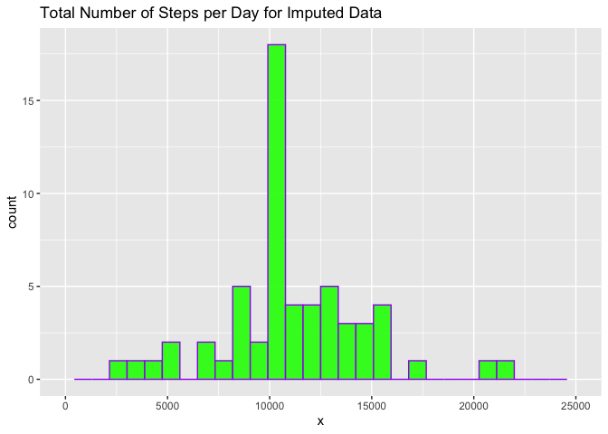

```r
steps_hist_imputed<- total_stepsperday_imputed %>%
            ggplot(aes(x=x)) +
            geom_histogram(fill="green",color = "purple", alpha=0.9)+
ggtitle("Total Number of Steps per Day for Imputed Data")+
xlim(0, 25000)
steps_hist_imputed
```

```r
summary(total_stepsperday_imputed)
```

```
##    Group.1                x
##  Length:61          Min.   :   41
##  Class :character   1st Qu.: 9819
##  Mode  :character   Median :10766
##                     Mean   :10766
##                     3rd Qu.:12811
##                     Max.   :21194
```

The mean and median of the total number of steps taken per day for the imputed data set is 10766 and 10766 respectively. The old mean was 10766 and median was 10765 (as reported above in the beginning of this document).

The mean and median for the imputed data set is the same.

## Are there differences in activity patterns between weekdays and weekends?

```r
data_imputed$date <-as.Date(data_imputed$date)
data_imputed$dayofweek<-weekdays(data_imputed$date)
data_imputed$weekend <-ifelse(data_imputed$dayofweek=="Saturday"           |data_imputed$dayofweek=="Sunday", "weekend", "weekday" )
```

### Panel Plot

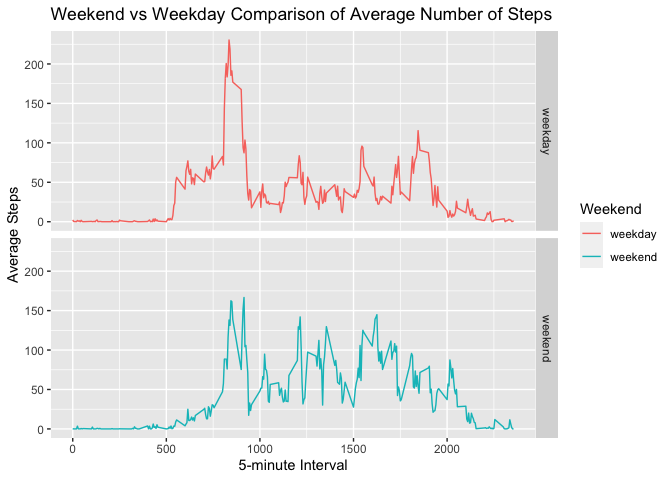

```r
agg_weekend <- aggregate(data_imputed$steps, by=list(data_imputed$interval, data_imputed$weekend), na.omit(mean))
names(agg_weekend) <- c("interval", "Weekend", "steps")

ggplot(agg_weekend, aes(x=interval, y = steps, color = Weekend)) + geom_line()+
  facet_grid(Weekend~.) +ggtitle("Weekend vs Weekday Comparison of Average Number of Steps")+ xlab("5-minute Interval") + ylab("Average Steps")
```